# Inside Your Screen: Exploring Everyday Phone Habits

## Why we Reach for our phones

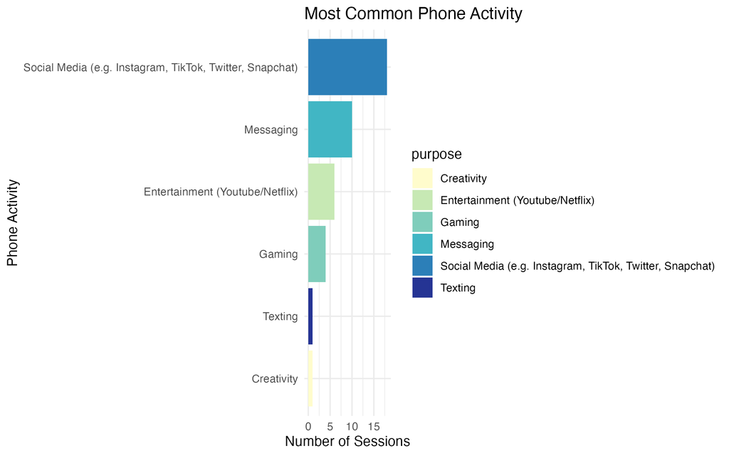

The most common phone activities observed during the observational logging process were social media, messaging and entertainment (Youtube/Netflix). Social media showed up most frequently, indicating that passive scrolling behaviours are heavily integrated into everyday routines. Many phone sessions appeared to begin automatically during moments of boredom or inactivity.

## Doomscrolling and Long Sessions

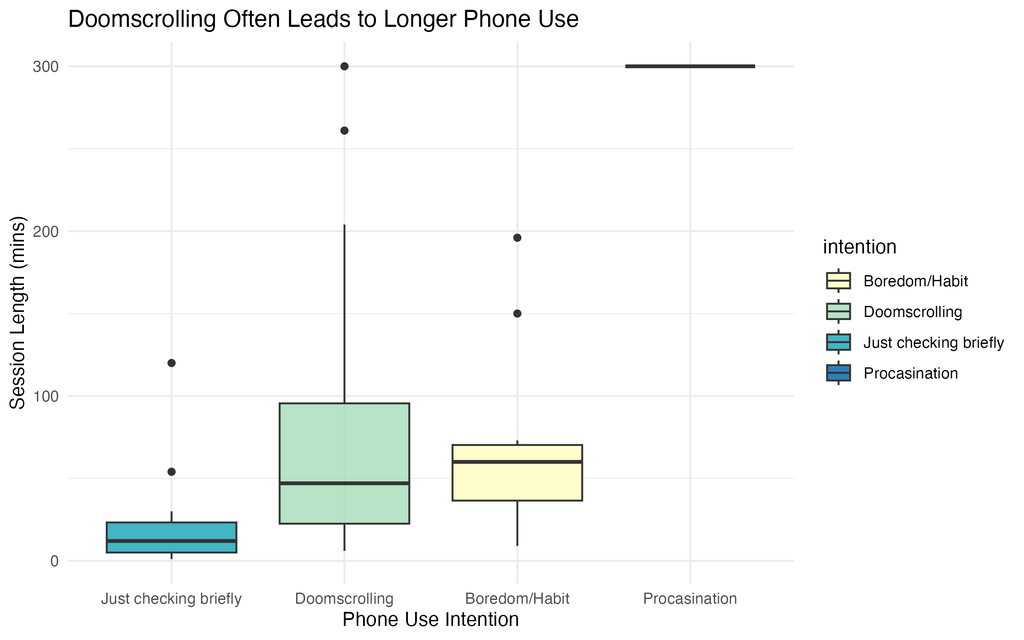

Boxplot comparing session lengths across different phone use intentions

## Phone Usage Across Different Times of Day

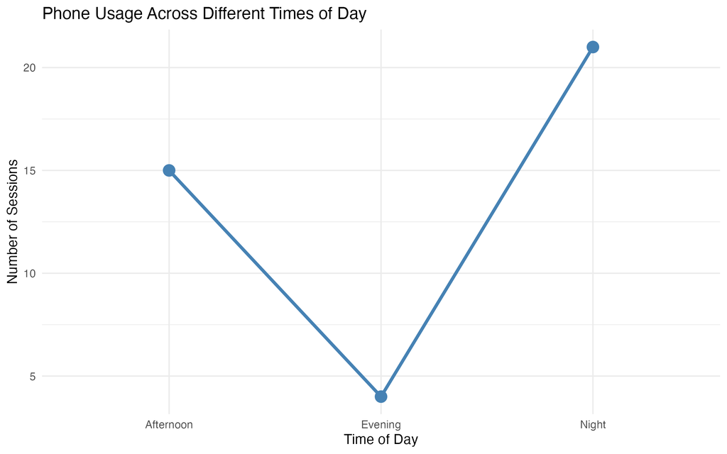

Line Graph of phone frequently using across different times of day

Phone activity increased during afternoon and night hours. This pattern may reflect people using their phones more frequently after classes, work, or during leisure time at home. The line graph highlights how smartphone us closely connected to daily routines and periods of downtime.

## Alone With our Screens

The observational data also showed that many phone sessions occured mostly alone time. Notification alerts and idle time were common triggers for phone use. Overall, the data suggests that chronic smartphone use becomes a habit rather than intention, especially during the moment of doomscrolling, boredom, procasination or passive entertainment.